# Introducation to R

Shanshan Wang  
sswang@buaa.edu.cn

School of Economics and Management  
Beihang University

# In this lecture we are going to learn …

- How to install and use **R**
- **R** basics
- **R** coding style
- Some nice **R** tips

# Why the software named as `R`?

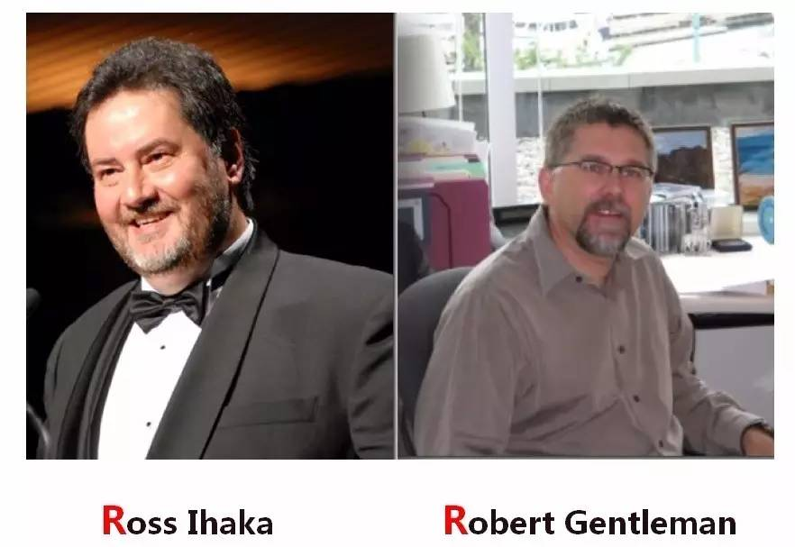

How to install and use **R**

# Getting and Installing R

- Totally free!
- Download R on its [official website](https://www.r-project.org).  
  -R for Windows  
  -R for Linux  
  -R for Mac
- Please install R in your own computer

# Examples

## Example 1

Generate random samples of size $100$ from standard Gaussian distribution, and calculate its mean and standard derivation.

```r
x<-rnorm(100,mean=0,sd=1)
mean(x)
```

```
## [1] 0.1205724
```

```r
sd(x)
```

```
## [1] 0.9317807
```

```r
summary(x)
```

```
##    Min. 1st Qu.  Median    Mean 3rd Qu.    Max.
## -2.0891 -0.5198  0.1025  0.1206  0.7739  2.0438
```

- Some Remarks:
  - Operation: `<-` (same as `=`)
  - Functions
    - `rnorm()`: random data from normal distribution
    - `mean()`: average of data
    - `sd()`: standard derivation of data
    - `summary()`: Report minimum,25% quantile, median, 75% quantile and maximum of data

## Example 2

[figure not shown]

```r
##input and output data
X1<-c(35, 40, 40, 42, 37, 45, 43, 37, 44, 42, 41, 39)
X1
```

```
##  [1] 35 40 40 42 37 45 43 37 44 42 41 39
```

```r
X2<-c(60, 74, 64, 71, 72, 68, 78, 66, 70, 65, 73, 75)
X2
```

```
##  [1] 60 74 64 71 72 68 78 66 70 65 73 75
```

```r
##mean and sd of X1 and X2
mu1<-mean(X1)
mu1
```

```
## [1] 40.41667
```

```r
sigma1<-sd(X1)
sigma1
```

```
## [1] 3.028901
```

```r
mu2<-mean(X2)
mu2
```

```
## [1] 69.66667
```

```r
sigma2<-sd(X2)
sigma2
```

```
## [1] 5.210712
```

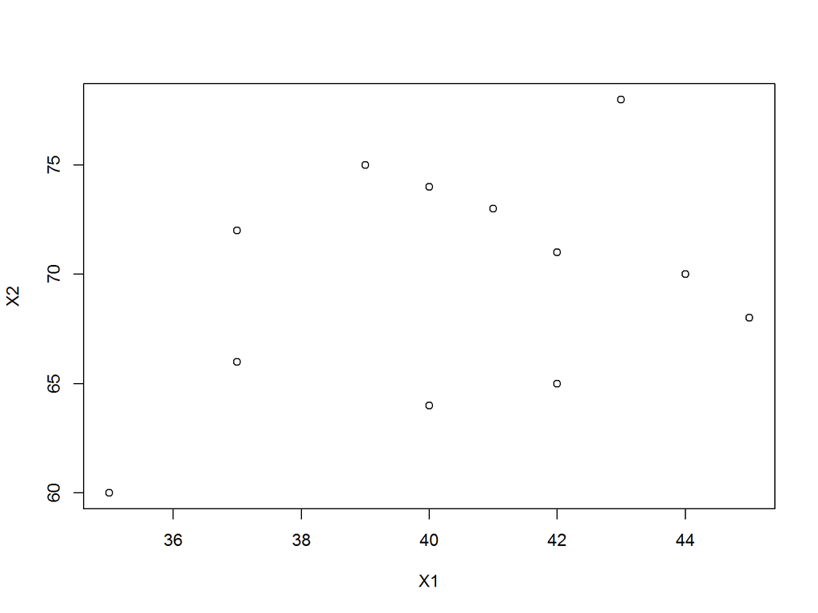

```r
##scatterplot&Histogram
plot(X1,X2)
```

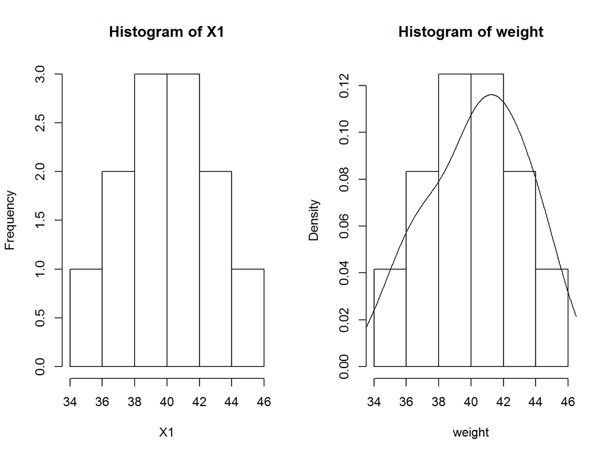

```r
par(mfrow=c(1,2))
hist(X1) # Histogram
hist(X1, probability = TRUE,main = paste("Histogram of" , "weight"),xlab = "weight")
lines(density(X1)) ##kernel
```

```r
##list and data frame
student.list<-list(weight=X1,height=X2)
student.list
```

```
## $weight
##  [1] 35 40 40 42 37 45 43 37 44 42 41 39
##
## $height
##  [1] 60 74 64 71 72 68 78 66 70 65 73 75
```

```r
student.df<-data.frame(weight=X1,height=X2)
student.df
```

```
##    weight height
## 1      35     60
## 2      40     74
## 3      40     64
## 4      42     71
## 5      37     72
## 6      45     68
## 7      43     78
## 8      37     66
## 9      44     70
## 10     42     65
## 11     41     73
## 12     39     75
```

# Why use R?

- Acdemic research
- Seeking job
- Free, open-source integrated development environment (IDE) for R.
- Rstudio: One of the most popular ways to run R.

[figure not shown]

# Packages required in this lecture

```
install.packages(c('foreign','MASS',`forecast`,'sos'))
```

#### R packages

- Standard R comes with some standard packages installed for basic data management, analysis, and graphical tools.
- More than 10,000 packages available on CRAN! See http://cran.r-project.org.
- `install.packages('foreign')` to install an package called ‘foreign’.
- `library(foreign)` before using the package.

**R** basics

# Basic Operations

```r
# simple maths
1 + 2 + 3
```

```
## [1] 6
```

```r
1 + 2 * 3
```

```
## [1] 7
```

```r
# assign a value to a variable
x <- 1
y <- 2
z <- c(x,y)
z
```

```
## [1] 1 2
```

```r
# function examples
exp(1)
```

```
## [1] 2.718282
```

```r
cos(3.141593)
```

```
## [1] -1
```

```r
log2(1)
```

```
## [1] 0
```

# Vectors

- Numerical vectors: `c()`,`rep()`,`seq()`
- Logical vectors: `TRUE` or `FALSE`
- Character vectors
- Length of a vector: `length(vector)`
- Vector calculations: `+,-,*,/`
- Extract some elements of a vector: `vector[location of elements]`

```r
# vectors
c(0, 1, 1, 2, 3, 5, 8)
```

```
## [1] 0 1 1 2 3 5 8
```

```r
1:10
```

```
##  [1]  1  2  3  4  5  6  7  8  9 10
```

```r
seq(1, 9, 2)
```

```
## [1] 1 3 5 7 9
```

```r
rep(1, 10)
```

```
##  [1] 1 1 1 1 1 1 1 1 1 1
```

```r
length(rep(1, 10))
```

```
## [1] 10
```

```r
# character vectors
c("Hello world", "Hello R interpreter")
```

```
## [1] "Hello world"         "Hello R interpreter"
```

```r
# vector calculation
c(1, 2, 3, 4) + c(10, 20, 30, 40)
```

```
## [1] 11 22 33 44
```

```r
c(1, 2, 3, 4) + 1
```

```
## [1] 2 3 4 5
```

```r
# you can refer to elements by location in a vector
b <- c(1,2,3,4,5,6,7,8,9,10,11,12)
length(b)
```

```
## [1] 12
```

```r
b
```

```
##  [1]  1  2  3  4  5  6  7  8  9 10 11 12
```

```r
b[7]
```

```
## [1] 7
```

```r
b[1:6]
```

```
## [1] 1 2 3 4 5 6
```

```r
b[c(1,6,11)]
```

```
## [1]  1  6 11
```

```r
b > 5
```

```
##  [1] FALSE FALSE FALSE FALSE FALSE  TRUE  TRUE  TRUE  TRUE  TRUE  TRUE
## [12]  TRUE
```

```r
b[b > 5]
```

```
## [1]  6  7  8  9 10 11 12
```

# Matrix

- Create a matrix: `matrix()`
- Dimension of a matrix: `dim()`
- Transpose of a matrix: `t()`
- Extract elements from a matrix:`matrix[location of rows,locations of column]`
- Combine two or more matrices: `rbind()`, `cbind()`

```r
# create a matrix
m <- matrix(c(1:6), 2, 3)
n <- matrix(c(8:13), 2, 3)
dim(m)
```

```
## [1] 2 3
```

```r
t(m)
```

```
##      [,1] [,2]
## [1,]    1    2
## [2,]    3    4
## [3,]    5    6
```

```r
m[1, 2]
```

```
## [1] 3
```

```r
m[1, ]
```

```
## [1] 1 3 5
```

```r
cbind(m, n)
```

```
##      [,1] [,2] [,3] [,4] [,5] [,6]
## [1,]    1    3    5    8   10   12
## [2,]    2    4    6    9   11   13
```

```r
rbind(m, n)
```

```
##      [,1] [,2] [,3]
## [1,]    1    3    5
## [2,]    2    4    6
## [3,]    8   10   12
## [4,]    9   11   13
```

# List

- Special data structure that matrix could not handle.
  - Data length are not the same.
  - Data type are not the same.
- Create a list: `list()`
- Extract elements of a list: `[[]]` or `$`

```r
l <- list(a = c(1, 2), b = 'apple')
l
```

```
## $a
## [1] 1 2
##
## $b
## [1] "apple"
```

```r
l$a
```

```
## [1] 1 2
```

```r
l$b
```

```
## [1] "apple"
```

# Data frame

- `data.frame()`: tightly coupled collections of variables which share many of the properties of matrices and of lists, used as the fundamental data structure by most of R’s modeling software.
- In most cases, the operation with a data frame is similar to matrix operation.

```r
L3 <- LETTERS[1:3]
fac <- sample(L3, 10, replace = TRUE)
d <- data.frame(x = 1, y = 1:10, fac = fac)
d
```

```
##    x  y fac
## 1  1  1   A
## 2  1  2   B
## 3  1  3   A
## 4  1  4   C
## 5  1  5   C
## 6  1  6   B
## 7  1  7   B
## 8  1  8   B
## 9  1  9   A
## 10 1 10   B
```

- Some Remarks:
  - Same length for each variable
  - Use `d$x` to Extract elements of a data frame